# US equity momentum: a statistical risk assessment

## What I built

The deliverable is this notebook: a dated assessment of US equity momentum, together with its calculations and historical tests. For a selected date it produces:

1. An estimate of next-week downside probability and a fifth-percentile outcome.
2. A description of recent losses, split between the long and short legs.
3. Estimated long and short responses to a specified market rise or fall.

I use public factor returns for these calculations. The company-level and options sections are separate examples of additional data analysis.

The added predictors did not consistently improve weekly loss forecasts beyond volatility. A simple rolling-beta regression had slightly lower pooled scenario error than the more complex regression. The historical loss analysis describes which leg contributed to losses over several return horizons.

The example below is dated **30 December 2022**, the last common date used for the original assessment. A separate evaluation covers **2023–July 2026**. In that period, weekly loss probabilities averaged 13.2% against 12.4% observed, with substantial annual variation. The 20-trading-day interim-loss model overpredicted breaches: 19.6% estimated against 9.3% observed.

Some later observations had already been examined during development; this extension is not an untouched test set. Whether the notebook improves a PM's decisions has not been tested. The appendix records the other specifications and their results.

The interim-loss section also reports GARCH and historical-path estimates side by side. GARCH improves the recent scores but not the earlier ones, so I report both rather than replace one with the other.

## Data and units

The reference exposure buys past stock-market winners and shorts past losers. I use the Kenneth French US momentum factor and size/momentum portfolios for the net factor and its legs. The market series is the market factor plus the risk-free return. [Data source: Kenneth French library](https://mba.tuck.dartmouth.edu/pages/faculty/ken.french/data_library.html).

Returns are **percentage points (pp)** on fixed long and short notionals. A +1 pp long contribution and −1.5 pp short contribution sum to −0.5 pp net. Multi-day values sum daily contributions; they are not returns on a specified fund's capital.

**One session means one trading day.** Five sessions means five trading days, approximately one week. The weekly forecast is scaled to five trading days but evaluated on Friday-ending calendar weeks: 339 of the original 2,035 weeks have fewer than five trading days. The interim-loss test uses exactly 20 subsequent trading days.

| Term | Meaning |
| --- | --- |
| q05 | Fifth percentile of the estimated return distribution |
| Lower-15% mean | Average of the worst 15% of historical return windows |
| Beta | Estimated change in a leg's contribution for a 1 pp market move |
| EWMA | Exponentially weighted moving average; recent observations receive more weight |
| FHS | Filtered historical simulation: historical returns rescaled to current estimated volatility |
| Bear state | Negative market return over the preceding 504 trading days |
| MAE / MSE | Mean absolute / squared error; lower is better |
| Brier / log loss | Probability-error scores; lower is better |
| PCA | Principal component analysis, used to summarise common stock-return movements |

Each dated calculation uses observations ending on or before that cutoff. The data are current-vintage histories rather than archived versions of each historical release. Model choices were made after examining results on this history.

**Exact public legs.** I use `SMALL HiPRIOR`, `BIG HiPRIOR`, `SMALL LoPRIOR` and `BIG LoPRIOR` from the six daily size/prior-return portfolios: $L=(SmallHigh+BigHigh)/2$, $S=-(SmallLow+BigLow)/2$, $Net=L+S$. The provider forms value-weighted portfolios daily using prior months 2–12 returns, the NYSE median size breakpoint and NYSE 30th/70th prior-return percentiles. [Provider construction](https://mba.tuck.dartmouth.edu/pages/faculty/ken.french/Data_Library/det_mom_factor_daily.html). I use published rounded Mom for the weekly event and the summed legs for attribution; rounding can produce differences below .02 pp per day.

**Target derivation.** The initial sample contains 522 Friday-ending weekly sums, 3 January 1964–28 December 1973. Its interpolated fifth percentile is −2.157 pp; the later comparisons use the rounded fixed threshold −2.16 pp.

| Calculation | Input/training history | Evaluated dates and exclusions |
| --- | --- | --- |
| Weekly probabilities and scenarios | Daily inputs start 2 January 1964; regression outcomes start 1974; expanding annual fits begin in 1984 | 3 January 1984–30 December 2022: 2,035 outcome weeks |
| Broader probability/shape comparisons | Same weekly construction and expanding training | 3 January 1984–24 July 2026: 2,221 weeks; conservative final weekly-bin exclusion |
| Recent weekly validation | Existing annual update rules | 186 additional weeks, January 2023–24 July 2026 |
| Historical-path/GARCH comparison | Completed weekly-start paths from 1974; GARCH daily history from 1964 | 2,030 cutoffs, 6 January 1984–25 November 2022; next twenty days must finish within 2022 |
| Recent path comparison | Same rules | 183 cutoffs, 6 January 2023–3 July 2026; full twenty-day outcome observed |

The conditional recent extension includes 31 July 2026, unlike the weekly probability panel's final-bin exclusion. Its 187 weeks are reported separately. Macro-input comparisons use common nonmissing 2000–2022 observations. The first daily values initialise trailing features; rows without completed lookbacks are excluded before fitting.

```python
from pathlib import Path
import sys, json, hashlib
import numpy as np
import pandas as pd
import matplotlib.pyplot as plt
from IPython.display import display, Markdown, clear_output, Image
from io import BytesIO
ROOT=Path.cwd()
if not (ROOT/'scripts/economic_companion.py').exists():
    raise RuntimeError('Run from the gpt-momentum repository root.')
sys.path.insert(0,str(ROOT/'scripts'))
from economic_companion import EconomicCompanion
from book_diagnostics import BookDiagnostics
from submission_view import SubmissionView
from economic_extension import OUT
E=EconomicCompanion(ROOT)
B=BookDiagnostics(ROOT)
P=SubmissionView(E)
P.verify()
qa=json.loads((OUT/'QA.json').read_text())
for name,expected in qa['hashes'].items():
    assert hashlib.sha256((ROOT/name).read_bytes()).hexdigest()==expected, f'Stale research artifact: {name}'
FIG=OUT/'figures';FIG.mkdir(exist_ok=True)
DATE='2022-12-31'
def show_figure(fig,name):
    fig.savefig(FIG/(name+'.png'),dpi=140,bbox_inches='tight')
    display(Image(filename=str(FIG/(name+'.png'))));plt.close(fig)
def show_inline(fig):
    buffer=BytesIO();fig.savefig(buffer,format='png',dpi=110,bbox_inches='tight')
    display(Image(data=buffer.getvalue()));plt.close(fig)
display(Markdown(P.assessment(DATE)))
```

Example output: 30 December 2022

These calculations use the public US momentum factor and its long and short legs. Returns are percentage points (pp) on the fixed-notional factor position.

| Calculation | Result |
| --- | --- |
| Estimated probability of losing more than 2.16 pp over approximately the next week | 19.7% |
| Estimated fifth-percentile weekly outcome | -5.50 pp |
| Average of the worst 15% of historical five-trading-day windows | -4.70 pp: long +1.89, short -6.59 |
| Conditional response if the market rises 2% | Long +1.81, short -2.78, net -0.97 pp |
| Conditional response if the market falls 2% | Long -1.66, short +2.83, net +1.17 pp |

The historical loss calculation uses 252 completed five-trading-day windows. The scenario entries are estimated average responses to the stated market moves. The trailing net market beta is -0.53. Applying these estimates to another portfolio would require its holdings. Forecast and scenario errors are reported below.

At this date, I would first examine the short leg: it accounts for most of the historical tail loss, and the negative market beta suggests vulnerability to a market rebound. I would check whether the actual portfolio shares that exposure; different holdings could change this priority. These estimates do not establish that a rebound is imminent.

The probability mainly reflects recent volatility. The scenarios are average historical responses, not stress-loss limits. In the two crisis examples below, net scenario errors are roughly 6–8 pp, including one wrong-sign estimate.

## 1. Weekly downside estimates

Here $r_t$ is daily factor P&L in pp, $Y_w$ is weekly factor P&L, and $\sigma_t$ is its estimated daily scale. The index $t$ denotes the information cutoff and $w$ a subsequent week.

1. The model estimates daily risk with an exponentially weighted mean of squared factor P&L: $\sigma_t^2=.94\sigma_{t-1}^2+.06r_t^2$ (initialised from the available history). Recent moves receive more weight; this is a scale estimate, not a reversal signal.
2. At each annual fit, the model retains 260 completed weekly shocks $z_w=Y_w/(\sqrt5\sigma_{\text{preceding cutoff}})$. The model keeps that sample fixed within the year. The weekly shock library is about five years of observations.
3. At each assessment cutoff, the model rescales each shock to $\tilde Y_i=\sqrt5\sigma_tz_i$. The model estimates loss probability as $(\#\{\tilde Y_i<-2.16\}+.5)/(260+1)$ and q05 as the empirical fifth percentile. The -2.16 pp threshold was fixed in the initial training-stage definition; it is a loss target, not proof of a reversal event.
4. I compared the loss estimates with a logistic model using the same EWMA scale to check whether the historical-return distribution added information beyond that volatility input. I report pooled and bear-state scores, q05 breaches and intervals calculated from blocks of consecutive weeks. Brier/log loss measure probability error (lower is better); mean predicted versus observed frequency checks average calibration, not every conditional calibration property.

Probability and q05 come from the same rescaled outcomes. The comparison below does not establish lower probability error than a logistic model using the same volatility input. In bear-state weeks, average estimated probability is below the observed loss frequency.

EWMA starts with $\sigma_0^2=r_0^2$ on 2 January 1964 (`adjust=False`). At each annual fit I take the **most recent** 260 eligible weekly shocks and keep them fixed for the year. For example, the first 1984 forecast covers 3–6 January and uses information through 30 December 1983. Subsequent annual fits use the last cutoff before the first outcome week starting in that year. Regression training uses all completed weekly outcomes from 1974 through that cutoff.

The historical-frequency comparator is the unsmoothed event fraction in that same expanding training sample. The two logit comparators use log 126-day sample SD or log EWMA respectively, training-standardise the input, and fit L2 logistic regression with C=1. Their coefficients and the frequency estimate update annually.

In the paired table, difference means historical-return model loss minus comparator loss; negative favours historical returns. lo/hi are pointwise 95% block-bootstrap bounds; block is the number of consecutive weeks sampled. The first alarm table uses probability ≥20% as its illustrative elevated level. An event run is consecutive weeks below −2.16 pp; a prior warning means the forecast for its first week was already ≥20% at the immediately preceding cutoff, not any earlier warning.

```
findfont: Failed to find font weight semibold, now using 700.
```

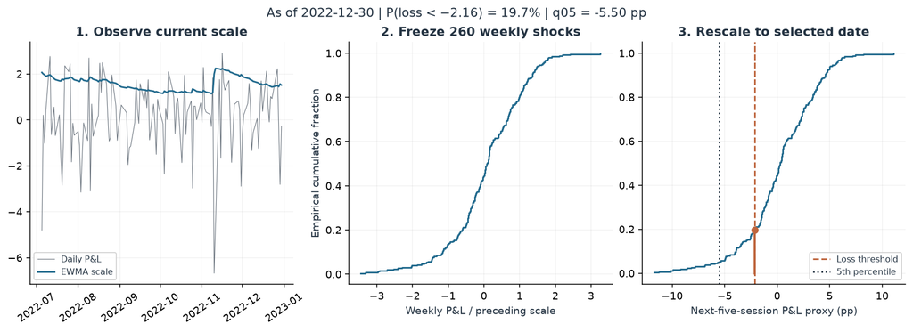

|  | model | state | weeks | events | predicted | observed | brier | log_loss | q05_breach |
| --- | --- | --- | --- | --- | --- | --- | --- | --- | --- |
| 0 | Historical frequency | all | 2035 | 182 | 0.0628 | 0.0894 | 0.0819 | 0.3046 | 0.0717 |
| 1 | Historical frequency | bear | 238 | 58 | 0.0651 | 0.2437 | 0.2164 | 0.7193 | 0.2101 |
| 3 | 126-session volatility logit | all | 2035 | 182 | 0.1006 | 0.0894 | 0.0738 | 0.2624 | — |
| 4 | 126-session volatility logit | bear | 238 | 58 | 0.2197 | 0.2437 | 0.1627 | 0.4979 | — |
| 6 | Matched EWMA logit | all | 2035 | 182 | 0.1062 | 0.0894 | 0.0734 | 0.2561 | — |
| 7 | Matched EWMA logit | bear | 238 | 58 | 0.2214 | 0.2437 | 0.1590 | 0.4897 | — |
| 9 | Retained empirical/volatility | all | 2035 | 182 | 0.0820 | 0.0894 | 0.0728 | 0.2553 | 0.055 |
| 10 | Retained empirical/volatility | bear | 238 | 58 | 0.1661 | 0.2437 | 0.1721 | 0.5180 | 0.0546 |

|  | comparator | metric | subset | n | events | difference | lo | hi | block |
| --- | --- | --- | --- | --- | --- | --- | --- | --- | --- |
| 73 | Matched EWMA logit | Brier | all | 2035 | 182 | -0.00058 | -0.00353 | 0.00270 | 26 |
| 76 | Matched EWMA logit | Brier | bear | 238 | 58 | 0.01305 | -0.00073 | 0.03467 | 26 |
| 91 | Matched EWMA logit | Log loss | all | 2035 | 182 | -0.00078 | -0.00745 | 0.00664 | 26 |
| 94 | Matched EWMA logit | Log loss | bear | 238 | 58 | 0.02836 | -0.00315 | 0.07459 | 26 |

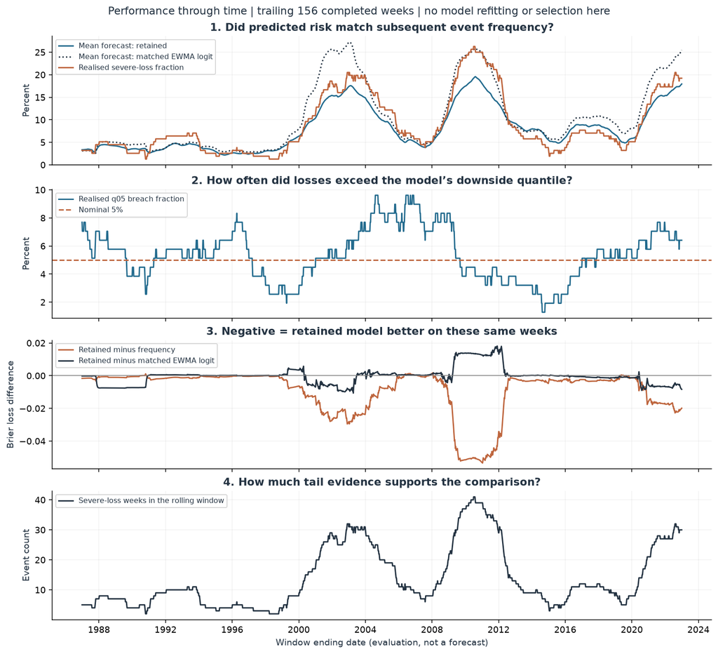

|  | Question | Count | Denominator |
| --- | --- | --- | --- |
| 0 | Elevated forecast weeks | 212 | 2035 |
| 1 | Elevated forecast + severe loss | 67 | 212 |
| 2 | Elevated forecast without severe loss | 145 | 212 |
| 3 | Severe loss below elevated threshold | 115 | 182 |
| 4 | Event runs elevated before first loss week | 39 | 135 |

```python
from through_time_v8 import performance_plot, episode_ledger, episode_plot, alarm_table
from distribution_panel import profile
C=E.core
show_figure(C.baseline(DATE),'baseline_recipe')
baseline_scores=C.scores()
display(baseline_scores.query("state in ['all','bear']").round(4).fillna('—'))
baseline_pairs=pd.DataFrame(C.audit['forward'])
display(baseline_pairs.query("comparator=='Matched EWMA logit' and block==26 and subset in ['all','bear']").round(5))
show_figure(performance_plot(C.evaluation,156,logit_col='p_logit_ewma'),'baseline_through_time')
display(alarm_table(C.evaluation))
```

## 2. Historical losses and leg contributions

1. At each assessment date, I calculated long, short and net returns over five-trading-day windows ending on each of the preceding 252 trading days.
2. I ranked those windows by net return and selected the worst 15%. I used a fractional weight on the final window where needed to represent exactly 15% of the sample.
3. I averaged each leg's contribution over those same windows because I wanted to describe the losses of the combined position. Using separate dates for each leg would answer a different question. I checked that the two contributions added to the average net loss.
4. I grouped overlapping selected windows and repeated the calculation after omitting the largest group. This helped me assess how much the description depended on one loss episode.

I selected the two dates below to illustrate similar average net losses with different leg contributions. The comparison describes what happened in those samples; it does not test whether the leg attribution predicts subsequent losses.

An episode joins selected windows sharing trading days, including indirect overlap. “Largest” means the largest sum of fractional tail weights times negative net-return magnitude. The episode loss share uses that amount divided by the corresponding amount across all selected windows. This is distinct from stock-level gross negative contributions.

```python
examples=[]
for t in ['2015-04-30','2018-11-30']:
    q=profile(C.sample(t,5,252).to_numpy(),5)
    examples.append({'Date':t,'All-window mean pp':q['mean'],'All-window SD pp':q['sd'],'Worst-15% mean pp':q['tail_mean'],
        'Long pp':q['long'],'Short pp':q['short'],'Connected episodes':q['episodes'],
        'Dominant leg survives omission':q['dominant_leg_survives']})
display(pd.DataFrame(examples).round(3))
display(Markdown('The two average tail losses are both about −2 pp. In April 2015, the short leg contributes most of the loss; in November 2018, the long leg does. The comparison describes those historical windows.'))
```

|  | Date | All-window mean pp | All-window SD pp | Worst-15% mean pp | Long pp | Short pp | Connected episodes | Dominant leg survives omission |
| --- | --- | --- | --- | --- | --- | --- | --- | --- |
| 0 | 2015-04-30 | 0.090 | 1.307 | -2.044 | -0.442 | -1.602 | 11 | True |
| 1 | 2018-11-30 | 0.134 | 1.314 | -2.078 | -2.108 | 0.029 | 11 | True |

The two average tail losses are both about −2 pp. In April 2015, the short leg contributes most of the loss; in November 2018, the long leg does. The comparison describes those historical windows.

## Market exposure over time

I estimate each leg's market beta from the preceding 252 trading days. The plots show the winner stocks' beta, the loser stocks' beta, and their difference. The short position contributes the negative of the loser stocks' return.

When the loser stocks have higher beta than the winners, net beta is negative. That suggests a market rally could hurt the factor, although the fitted relationship will not explain every outcome. These estimates describe the historical strategy as its constituents change.

The plotted positive-market slope comes from the daily OLS regression $r_{\ell,s}=a+bM_s+c\max(M_s,0)+e_s$ over the preceding 252 trading days. Its negative-side slope is b and positive-side slope is b+c. I sum signed leg slopes; $g_t=c_L+c_S$ is the net difference used in the weekly alternative regression.

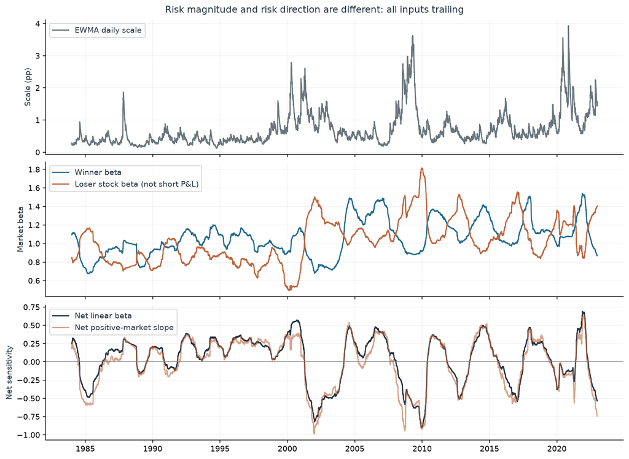

```python
show_figure(E.exposure_plot(DATE),'01_exposures')
```

## 3. Estimated responses to a market move

I use a rolling-beta model to estimate each leg's average weekly response:

$$\widehat Y_{\ell,w}=\widehat a_{\ell,y}+\beta_{\ell,t}M_w.$$

Here $\ell$ denotes the long or short leg, $w$ the week, $t$ the preceding cutoff, and $y$ the annual fit. $M_w$ is the market move being considered, in pp.

1. The model estimates each leg's beta from the preceding 252 daily observations: $\beta_{\ell,t}=\operatorname{Cov}(r_\ell,M)/\operatorname{Var}(M)$.
2. At each annual fit, the model estimates the intercept as the average completed weekly leg return minus its trailing beta times the realised weekly market return.
3. The model inserts a market move, such as +2 pp, into each leg’s equation and adds the two responses to obtain the net response.
4. I evaluated the relationship using subsequent realised market moves and leg returns. This measures conditional response error; the market move is an input.

### Alternative regression

I also fitted a model allowing different slopes in rising and falling markets, different market states, and changing measured exposures:

$$Y_{\ell,w}=a_\ell+b_\ell M_w+c_\ell M_w^+ +d_\ell B_t+e_\ell B_tM_w+f_\ell B_tM_w^+ +u_\ell\beta_{net,t}M_w+v_\ell g_tM_w^++\varepsilon_{\ell,w}.$$

$M_w^+=\max(M_w,0)$ and $B_t$ is the bear-state indicator. The input $g_t$ is the difference between the net rising- and falling-market slopes, estimated over the preceding 252 trading days. Coefficients are fitted annually using completed prior weeks, while trailing inputs update during the year.

The volatility comparator replaces the final two terms with $\log(s_t)M_w$ and $\log(s_t)M_w^+$, where $s_t=\sqrt5\sigma_t$. It has the same number of regressors. This tests whether exposure information improves on volatility in this specification.

Intervals for the alternative model's average response use 300 resamples of 26-week training blocks. They hold input betas fixed and exclude future residual variation, so they do not describe the range of a future realised return. The table also counts training weeks with the same bear state, market moves within 1 pp, log scale within .35, net beta within .3, and rising/falling slope differences within .75. These counts indicate how much similar history is available; they are not independent sample sizes.

For the selected model the annual intercept is $\hat a_{\ell,y}=|T_y|^{-1}\sum_{w\in T_y}(Y_{\ell,w}-\beta_{\ell,t(w)}M_w)$, where $T_y$ contains completed weeks from 1974 through the first forecast cutoff of year y. Each training week uses its own preceding beta, not the current beta.

| Saved model label | Specification |
| --- | --- |
| rolling | Selected beta model and annual residual-mean intercept |
| static | First six terms of the alternative equation: intercept, M, M+, bear, bear×M, bear×M+ |
| dynamic | static plus net-beta×M and slope-gap×M+ |
| vol_response | static plus log-scale×M and log-scale×M+ |
| full_response | static plus both exposure and volatility pairs |

The original error and lookback tables report **net weekly** MAE in pp and MSE in pp². Changing the exposure lookback changes rolling/dynamic/full exposure inputs, while static and volatility-only regressors remain unchanged. The displayed lines are point estimates; the bootstrap-mean intervals described above are calculated in the underlying scenario output but are not plotted in this comparison figure.

**The solid line shows rolling beta; the dashed net line shows the nonlinear model.** Neither curve is a realised-loss bound.

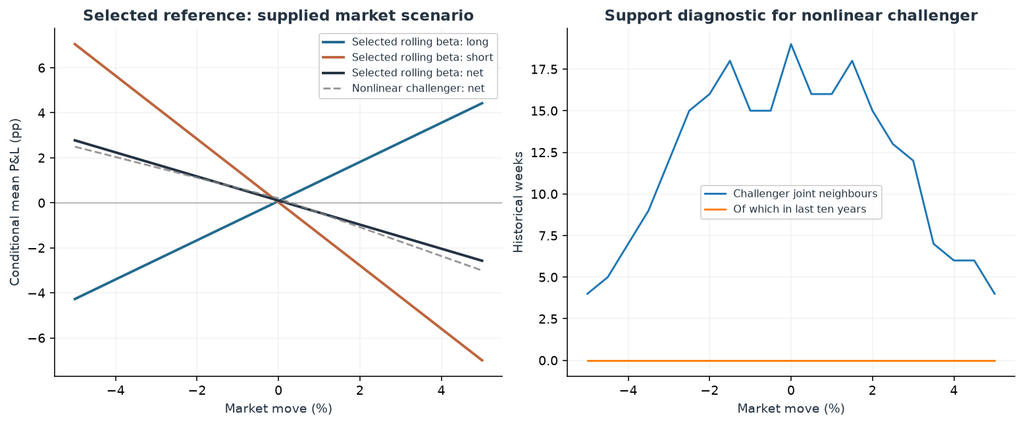

|  | Historical cutoff | Supplied market move | Simple net pp | Richer net pp | Richer joint support | Recent joint support |
| --- | --- | --- | --- | --- | --- | --- |
| 0 | 2008-12-31 | +2% | -0.76 | -0.97 | 1 | 1 |
| 1 | 2020-03-31 | +2% | 0.06 | -0.08 | 46 | 30 |
| 2 | 2022-12-31 | +2% | -0.97 | -1.08 | 15 | 0 |

These are dated hypothetical assessments, not realised event outcomes. The comparison shows whether the richer model changes the exposure diagnosis; it does not establish better stress-loss magnitudes.

```python
display(Markdown('**The solid line shows rolling beta; the dashed net line shows the nonlinear model.** Neither curve is a realised-loss bound.'))
show_figure(P.scenario_plot(DATE),'02_conditional_response')
case_rows=[]
for case_date in ['2008-12-31','2020-03-31','2022-12-31']:
    simple=P.rolling(case_date,2)
    richer=E.scenarios(case_date).query('market==2').iloc[0]
    case_rows.append({'Historical cutoff':case_date,'Supplied market move':'+2%',
        'Simple net pp':round(sum(simple.values()),2),'Richer net pp':round(richer.net,2),
        'Richer joint support':int(richer.nearby_joint),'Recent joint support':int(richer.nearby_joint_recent)})
display(pd.DataFrame(case_rows))
display(Markdown('These are dated hypothetical assessments, not realised event outcomes. The comparison shows whether the richer model changes the exposure diagnosis; it does not establish better stress-loss magnitudes.'))
```

## Scenario errors through 2022

For each week I calculate the response using that week's realised market move and compare it with the realised factor and leg returns. The tables report MAE and MSE. The paired differences subtract the volatility comparator's error from the exposure model's error, so negative values favour the exposure model. The intervals resample blocks of consecutive weeks; they do not account for selection among the models tried.

|  | subset | model | n | MAE | MSE |
| --- | --- | --- | --- | --- | --- |
| 0 | all | static | 2035 | 1.3580 | 4.2080 |
| 1 | all | rolling | 2035 | 1.3126 | 3.8277 |
| 2 | all | dynamic | 2035 | 1.3176 | 3.8355 |
| 3 | all | vol_response | 2035 | 1.3606 | 4.1830 |
| 4 | all | full_response | 2035 | 1.3188 | 3.8095 |
| 25 | 2017_2022 | static | 313 | 1.8523 | 7.5710 |
| 26 | 2017_2022 | rolling | 313 | 1.7682 | 6.5718 |
| 27 | 2017_2022 | dynamic | 313 | 1.7656 | 6.5289 |
| 28 | 2017_2022 | vol_response | 313 | 1.8095 | 7.0756 |
| 29 | 2017_2022 | full_response | 313 | 1.7597 | 6.3788 |
| 30 | exclude_crises | static | 1877 | 1.2002 | 3.0384 |
| 31 | exclude_crises | rolling | 1877 | 1.1675 | 2.8003 |
| 32 | exclude_crises | dynamic | 1877 | 1.1720 | 2.8241 |
| 33 | exclude_crises | vol_response | 1877 | 1.2024 | 3.0311 |
| 34 | exclude_crises | full_response | 1877 | 1.1748 | 2.8320 |

|  | subset | model | baseline | metric | block | n | years_better | years | delta | lo | hi |
| --- | --- | --- | --- | --- | --- | --- | --- | --- | --- | --- | --- |
| 19 | all | dynamic | vol_response | MAE | 26 | 2035 | 19 | 39 | -0.0430 | -0.0811 | -0.0079 |
| 20 | all | dynamic | vol_response | MAE | 52 | 2035 | 19 | 39 | -0.0430 | -0.0821 | -0.0093 |
| 169 | 2017_2022 | dynamic | vol_response | MAE | 26 | 313 | 4 | 6 | -0.0439 | -0.1610 | 0.0535 |
| 170 | 2017_2022 | dynamic | vol_response | MAE | 52 | 313 | 4 | 6 | -0.0439 | -0.1616 | 0.0474 |
| 199 | exclude_crises | dynamic | vol_response | MAE | 26 | 1877 | 17 | 36 | -0.0304 | -0.0647 | 0.0005 |
| 200 | exclude_crises | dynamic | vol_response | MAE | 52 | 1877 | 17 | 36 | -0.0304 | -0.0706 | 0.0010 |

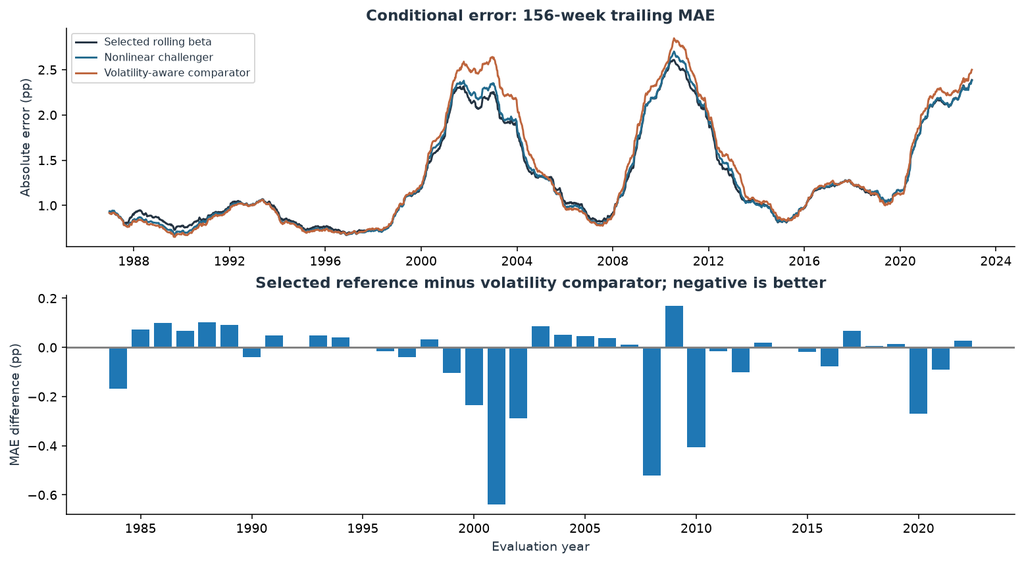

```python
scores=pd.read_json(OUT/'conditional_scores_252.json')
pairs=pd.read_json(OUT/'conditional_pairs_252.json')
display(scores.query("subset in ['all','2017_2022','exclude_crises']").round(4))
display(pairs.query("model=='dynamic' and baseline=='vol_response' and metric=='MAE' and block in [26,52] and subset in ['all','2017_2022','exclude_crises']").round(4))
show_figure(P.performance_plot(),'03_validation')
```

**Results through 2022.** The nonlinear exposure model reduces pooled MAE from 1.361 to 1.318 pp (about 3.2%); both 26- and 52-week paired intervals exclude zero. Average error in 2017–2022 also falls, but its interval spans zero. Excluding 2008–09 and 2020, MAE improves by about .030 pp, with intervals narrowly crossing zero; MSE still improves with intervals below zero. Only 19 of 39 years have lower MAE. The improvement over this comparator varies across years and subsets.

A simpler rolling-beta response is slightly better: pooled MAE/MSE **1.3126 / 3.8277**, versus **1.3176 / 3.8355** for the nonlinear challenger. I use rolling beta in the opening assessment because it had slightly lower pooled error. I selected it after examining these results. The rolling model is used to describe dated market exposure. The richer regression does not improve on it in these pooled results.

```python
sensitivity=[]
for w in [126,252,504]:
    s=pd.read_json(OUT/f'conditional_scores_{w}.json').query("subset=='all'")
    sensitivity.append({'Exposure lookback':w,**s.set_index('model').MAE.to_dict()})
display(pd.DataFrame(sensitivity).round(4))
```

|  | Exposure lookback | static | rolling | dynamic | vol_response | full_response |
| --- | --- | --- | --- | --- | --- | --- |
| 0 | 126 | 1.358 | 1.2563 | 1.2567 | 1.3606 | 1.2602 |
| 1 | 252 | 1.358 | 1.3126 | 1.3176 | 1.3606 | 1.3188 |
| 2 | 504 | 1.358 | 1.3705 | 1.3642 | 1.3606 | 1.3655 |

The 126-trading-day version has lower historical error than the 252-day version; the 504-day version loses the improvement over the volatility comparator. I keep the original 252-day window and report these alternatives as sensitivities. The results leave uncertainty about how quickly exposure estimates should adapt.

### Distribution-shape tests

I tested four separately defined targets, each with its own comparators: large negative/positive weekly returns and negative/positive **standardised return surprises**. Both tails use preceding EWMA scale; all predictor values precede the outcome.

| Target | Scale-only log loss | With state variables |
| --- | --- | --- |
| Absolute left | .26428 | .27480 |
| Absolute right | .30841 | .31289 |
| Negative standardised surprise | .26234 | .26682 |
| Positive standardised surprise | .34079 | .34145 |

State variables worsen log loss on all four targets. This is not four independent confirmations: targets and training samples overlap. The broader comparison also included **weekly skew-t GJR-GARCH** and GARCH-scaled historical simulation. Across its 2,221-week research sample, weekly skew-t GJR log loss is .26510 versus .26376 for EWMA historical simulation; no general GARCH inferiority is established. These are archived broader-sample tests that include the previously examined extended evaluation, **not** the 2,035-week, through-2022 main comparison. The definitions are given below and repeated in Appendix E04.

**Multiplicity:** the reported 26/52-week intervals are pointwise comparisons, not family-wise or selection-adjusted confidence statements across the full research search. Trying many related specifications increases the chance of apparently favourable results; an interval excluding zero is exploratory evidence, not a confirmed discovery. Some earlier model-family tests used their own search adjustment, but no single correction covers the earlier experiment families. A future locked, prospective evaluation is needed to confirm any selected gain.

For these tests, $Y_w$ is summed weekly factor P&L and $z_w=Y_w/(\sqrt5\sigma_t)$ uses EWMA scale at the preceding cutoff. The four events are $Y_w<-2.16$, $Y_w>2.16$, $z_w<-1.5$ and $z_w>1.5$. The scale logit uses log EWMA. The state logit adds log 126-day market volatility, the bear indicator, trailing 252-day factor beta, trailing 21-day compounded market return, and the three bear interactions listed below. Both use training-standardised inputs and L2 logistic regression with C=1, refitted annually on expanding completed weeks from 1974. The state feature list is log scale, log market volatility, bear, beta, rally, bear×log market volatility, bear×beta and bear×rally. These are the definitions behind the four rows.

## Recent-period validation: 2023–July 2026

**Result: the simple reference models remain competitive, while recent path probabilities overpredict breaches.** This extension does not establish a new predictive signal. The earlier through-2022 worked assessment remains historical; it is not the latest forecast.

1. **What was frozen:** the −2.16 pp weekly loss threshold, EWMA .94, 260-shock history, 252-session exposure lookback, 20-trading-day/−5 pp path target, 1,260-path history and existing logistic penalties. Annual chronological refits and trailing inputs update as previously specified. No specification was retuned after these results.
2. **What was extended:** cached public factor and academic leg data through 31 July 2026. Weekly risk evaluation ends 24 July (the existing procedure conservatively drops the last weekly bin); conditional response evaluation ends 31 July; path cutoffs end 3 July so all 20 future sessions are observed. Company-level and options coverage is not extended.
3. **What was checked:** all 2,035 historical weekly forecasts, 2,035 conditional forecasts and 2,030 path forecasts reproduce the saved pre-2023 results within numerical tolerance. Unfinished outcomes cannot enter training. Conditional tests supply the realised market move to evaluate a scenario relationship, not an unconditional forecast.
4. **Prior use of the sample:** these observations were examined in earlier work. The protocol for this calculation was recorded before it ran; the full project protocol developed during the research. Current-vintage factor data are not a point-in-time publication archive.

The executed tables follow the weekly, conditional-response and path summaries below.

### Weekly downside: reasonable pooled frequency, uneven through time

The logistic comparator is slightly better on both scores. The retained model's log-loss difference is +.00229; its 26-week block interval [−.00433, +.01124] spans zero. There is no demonstrated superiority over that comparator. The q05 forecast is breached in 4/186 weeks (2.15%, versus nominal 5%); pinball loss is .19767 pp. Pinball loss scores a forecast quantile, penalising observations below a fifth-percentile forecast 19 times as heavily as equally distant observations above it; lower is better. The fifth-percentile estimates were breached less often than their nominal 5% rate in this sample.

The annual results show underprediction in 2023 and overprediction in 2024. Only 33 weekly bear-state observations, containing six losses, are available; that provides limited evidence about performance in bear states. Zero 2024 path events does not prove the probabilities should have been zero.

### Conditional response: rolling beta has the lowest error

Across 187 weeks the rolling reference has .0294 pp lower MAE than the nonlinear challenger; the 26-week interval is [−.0606, −.0010]. The MSE interval spans zero. The challenger's small MAE advantage over the volatility-response comparator also has an interval spanning zero. I retain rolling beta because its average error is lower in these comparisons.

### Path risk: useful distinction, weak recent probability calibration

Across 183 cutoffs, the empirical path model estimates 19.59% breach probability against 17/183 observed breaches (9.29%). The volatility logistic also overpredicts (19.48%). Their log losses are .32231 and .32039, respectively; the paired 26-week interval for the difference is [−.00218, +.00604]. Switching between them does not solve the calibration weakness.

Only eight paths finish beyond −5 pp: nine of the 17 breached paths recover above the barrier before the endpoint. The endpoint measure therefore omits nine observed interim breaches. The probability estimates still overpredict the recent breach frequency. These are overlapping windows, not 17 independent crashes.

Intervals use 1,000 fixed-seed moving-calendar-block draws at both 13 and 26 weeks. They are pointwise, short-sample and unadjusted for the wider selection after trying many specifications. A few recent years cannot establish stability or a structural post-2010 breakdown. The existing specifications are unchanged. Prediction rows, annual scores, paired intervals, source hashes and replay checks accompany the reproduction package.

Computed by scripts/recent_validation.py; protocol and saved results. The following cell loads the saved scores and paired intervals; it does not refit the models.

```python
recent_scores = pd.read_json(ROOT/'research/recent_validation/scores.json')
recent_pairs = pd.read_json(ROOT/'research/recent_validation/pairs.json')
recent_pooled = recent_scores.loc[recent_scores.period.eq('2023+')].copy()
recent_labels = {'p_fhs5y_ewma':'Weekly historical/EWMA',
    'p_logit_ewma':'Weekly EWMA logit', 'p_frequency':'Weekly historical frequency',
    'p_fhs':'20-day historical paths', 'p_vol':'20-day volatility logit',
    'rolling':'Rolling beta', 'dynamic':'Nonlinear exposure',
    'vol_response':'Volatility response'}
recent_pooled['Model'] = recent_pooled.model.map(recent_labels)
display(Markdown('**Recent probability scores: 2023–July 2026**'))
display(recent_pooled.loc[recent_pooled.component.ne('conditional'),
    ['Model','n','events','predicted','observed','brier','logloss']].rename(columns={
    'n':'Weeks / cutoffs','events':'Losses / breaches','predicted':'Estimated',
    'observed':'Observed','brier':'Brier','logloss':'Log loss'}).style.hide(axis='index').format({
    'Losses / breaches':'{:.0f}','Estimated':'{:.2%}','Observed':'{:.2%}',
    'Brier':'{:.6f}','Log loss':'{:.6f}'}))
display(Markdown('**Recent conditional response errors: 187 weeks**'))
display(recent_pooled.loc[recent_pooled.component.eq('conditional'),
    ['Model','mae','mse']].rename(columns={'mae':'Net MAE, pp','mse':'Net MSE, pp²'})
    .style.hide(axis='index').format({'Net MAE, pp':'{:.4f}','Net MSE, pp²':'{:.4f}'}))
display(Markdown('**Annual historical-model frequencies (2026 is partial)**'))
recent_annual = recent_scores.loc[recent_scores.period.ne('2023+') &
    recent_scores.model.isin(['p_fhs5y_ewma','p_fhs']),
    ['component','period','n','events','predicted','observed']]
display(recent_annual.rename(columns={'component':'Target','period':'Year','n':'Weeks / cutoffs',
    'events':'Losses / breaches','predicted':'Estimated','observed':'Observed'})
    .style.hide(axis='index').format({'Losses / breaches':'{:.0f}',
    'Estimated':'{:.2%}','Observed':'{:.2%}'}))
display(Markdown('**Paired differences: model minus comparator, 26-week blocks; pointwise 95% intervals**'))
recent_comparisons = recent_pairs.loc[recent_pairs.block.eq(26)].copy()
recent_comparisons['model'] = recent_comparisons.model.map(recent_labels)
recent_comparisons['baseline'] = recent_comparisons.baseline.map(recent_labels)
display(recent_comparisons[['model','baseline','metric','difference','lo','hi']]
    .style.hide(axis='index').format({'difference':'{:.5f}','lo':'{:.5f}','hi':'{:.5f}'}))
recent_week = recent_pooled.loc[recent_pooled.model.eq('p_fhs5y_ewma')].iloc[0]
recent_path = recent_pooled.loc[recent_pooled.model.eq('p_fhs')].iloc[0]
display(Markdown(f"q05 breaches: {recent_week.q05_breaches:.0f}/{recent_week.n:.0f} "
    f"({recent_week.q05_breach_rate:.2%}); pinball loss: {recent_week.pinball:.5f} pp. "
    f"Bear-state weeks/losses: {recent_week.bear_weeks:.0f}/{recent_week.bear_events:.0f}. "
    f"Path endpoint breaches: {recent_path.endpoint_events:.0f}; interim breaches "
    f"that recovered above the barrier: {recent_path.recovered:.0f}."))
```

**Recent probability scores: 2023–July 2026**

| Model | Weeks / cutoffs | Losses / breaches | Estimated | Observed | Brier | Log loss |
| --- | --- | --- | --- | --- | --- | --- |
| Weekly historical/EWMA | 186 | 23 | 13.17% | 12.37% | 0.104425 | 0.356248 |
| Weekly EWMA logit | 186 | 23 | 14.15% | 12.37% | 0.103648 | 0.353955 |
| Weekly historical frequency | 186 | 23 | 8.45% | 12.37% | 0.110003 | 0.383599 |
| 20-day historical paths | 183 | 17 | 19.59% | 9.29% | 0.087938 | 0.322307 |
| 20-day volatility logit | 183 | 17 | 19.48% | 9.29% | 0.087098 | 0.320387 |

**Recent conditional response errors: 187 weeks**

| Model | Net MAE, pp | Net MSE, pp² |
| --- | --- | --- |
| Rolling beta | 1.5964 | 4.0649 |
| Nonlinear exposure | 1.6258 | 4.1358 |
| Volatility response | 1.6381 | 4.1316 |

**Annual historical-model frequencies (2026 is partial)**

| Target | Year | Weeks / cutoffs | Losses / breaches | Estimated | Observed |
| --- | --- | --- | --- | --- | --- |
| weekly | 2023 | 52 | 10 | 12.55% | 19.23% |
| weekly | 2024 | 52 | 1 | 10.54% | 1.92% |
| weekly | 2025 | 52 | 8 | 13.26% | 15.38% |
| weekly | 2026 | 30 | 4 | 18.68% | 13.33% |
| path | 2023 | 52 | 9 | 20.23% | 17.31% |
| path | 2024 | 52 | 0 | 14.22% | 0.00% |
| path | 2025 | 52 | 5 | 20.29% | 9.62% |
| path | 2026 | 27 | 3 | 27.33% | 11.11% |

**Paired differences: model minus comparator, 26-week blocks; pointwise 95% intervals**

| model | baseline | metric | difference | lo | hi |
| --- | --- | --- | --- | --- | --- |
| Weekly historical/EWMA | Weekly EWMA logit | brier | 0.00078 | -0.00135 | 0.00364 |
| Weekly historical/EWMA | Weekly EWMA logit | logloss | 0.00229 | -0.00433 | 0.01124 |
| 20-day historical paths | 20-day volatility logit | brier | 0.00084 | -0.00058 | 0.00236 |
| 20-day historical paths | 20-day volatility logit | logloss | 0.00192 | -0.00218 | 0.00604 |
| Rolling beta | Nonlinear exposure | mae | -0.02937 | -0.06058 | -0.00104 |
| Rolling beta | Nonlinear exposure | mse | -0.07091 | -0.18095 | 0.04435 |
| Nonlinear exposure | Volatility response | mae | -0.01233 | -0.09530 | 0.07212 |
| Nonlinear exposure | Volatility response | mse | 0.00415 | -0.36642 | 0.34339 |

q05 breaches: 4/186 (2.15%); pinball loss: 0.19767 pp. Bear-state weeks/losses: 33/6. Path endpoint breaches: 8; interim breaches that recovered above the barrier: 9.

## Historical cases: exposure, macro context and subsequent returns

I use two selected cases to examine how the exposure estimates relate to the economic backdrop and where they miss the outcome. The sources below were published before each cutoff. I selected and read them retrospectively; these paragraphs are not records of forecasts I made at the time. The figures include later returns, separated by the assessment marker. The earlier similar-loss comparison remains a separate historical description of which leg contributed to the loss.

Rebound exposure: March 2009

**Assessment cutoff: 06 March 2009, after the close.** I selected this case from the existing loss-week results to examine a rebound with an elevated prior probability. Both cases use the next five trading days for the outcome. The selection is retrospective.

| Information at the cutoff | Value |
| --- | --- |
| Prior two-year market return | -47.9% |
| Winner-stock beta | 0.89 |
| Loser-stock beta | 1.42 |
| Net beta | -0.53 |
| Estimated probability of next-week loss beyond 2.16 pp | 29.3% |
| Estimated net response to a +2% market move | -0.91 pp |
| Estimated net response to a −2% market move | +1.20 pp |

**Contemporaneous context.** On 3 March, Bernanke described a sharp economic contraction, some easing of funding strains, and continued financial stress. He discussed recovery as conditional on stabilising financial conditions. [Federal Reserve testimony, 3 March 2009](https://www.federalreserve.gov/newsevents/testimony/bernanke20090303a.htm).

**Interpretation using information through the cutoff.** A weak economy and an adverse rebound exposure can coexist: asset prices can respond to improving financing conditions or reduced downside expectations before activity recovers. The higher loser-stock beta suggests that a rally could hurt the short leg more than it helped the long leg. The statement does not establish that a rally was imminent.

I would examine whether the beta difference was concentrated in financial or other financing-sensitive stocks, and whether their credit spreads and earnings expectations were changing. A sector concentration or a few unusually responsive stocks could also explain the aggregate exposure. Reliable dated holdings and credit data would be needed to distinguish these possibilities.

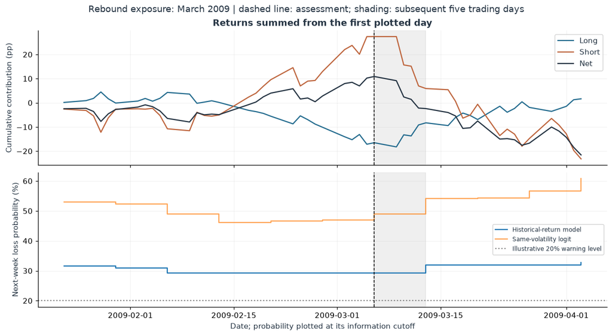

**Subsequent outcome: 09 March–13 March 2009.** The market returned +10.71%. Momentum returned -13.28 pp (published rounded factor: -13.28 pp).

| Contribution, pp | Conditional estimate using the subsequently realised market move | Realised | Realised minus estimate |
| --- | --- | --- | --- |
| Long | +9.66 | +8.23 | -1.43 |
| Short | -15.16 | -21.50 | -6.35 |
| Net | -5.49 | -13.28 | -7.78 |

This table uses the realised market move only to evaluate the conditional relationship; that move was not known at the cutoff.

The short leg lost more than the long leg gained, consistent with the direction suggested by the trailing betas. The regression nevertheless understated the net loss substantially, mainly through the short leg. The 29.3% weekly loss probability was already above the illustrative 20% threshold before the rebound, following earlier volatility. That does not establish that the model identified a turning point or the source of the rally.

A loss without a prior warning: March 2020

**Assessment cutoff: 13 March 2020, after the close.** I selected this case from the existing loss-week results because a loss occurred when its prior estimated probability was below the illustrative 20% warning threshold. Both cases use the next five trading days for the outcome. The selection is retrospective.

| Information at the cutoff | Value |
| --- | --- |
| Prior two-year market return | -0.1% |
| Winner-stock beta | 1.00 |
| Loser-stock beta | 1.16 |
| Net beta | -0.16 |
| Estimated probability of next-week loss beyond 2.16 pp | 14.8% |
| Estimated net response to a +2% market move | -0.20 pp |
| Estimated net response to a −2% market move | +0.43 pp |

**Contemporaneous context.** On 3 March, the FOMC cut its target range by half a percentage point, citing coronavirus risks to economic activity. That action and the market losses already observed were available by this cutoff. [FOMC statement, 3 March 2020](https://www.federalreserve.gov/newsevents/pressreleases/monetary20200303a.htm).

**Interpretation using information through the cutoff.** The negative net beta suggests some protection against a broad market decline in the fitted relationship. I would be cautious about extending that relationship to an abrupt change in company cash-flow prospects. Different exposures to disrupted revenues, refinancing needs or liquidity could change the relative performance of winners and losers.

I would check the sector and company contributions before assuming that the short leg would offset losses on the long leg. Distinguishing changed business exposures from selling pressure would require company information, holdings and flow data that the aggregate factor does not provide. These are possible explanations to examine, not findings from the model.

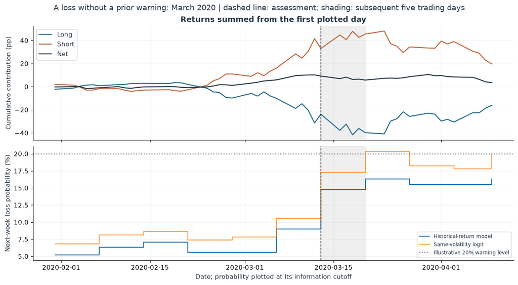

**Subsequent outcome: 16 March–20 March 2020.** The market returned -14.52%. Momentum returned -3.49 pp (published rounded factor: -3.49 pp).

| Contribution, pp | Conditional estimate using the subsequently realised market move | Realised | Realised minus estimate |
| --- | --- | --- | --- |
| Long | -14.43 | -15.95 | -1.52 |
| Short | +16.83 | +12.46 | -4.37 |
| Net | +2.40 | -3.49 | -5.89 |

This table uses the realised market move only to evaluate the conditional relationship; that move was not known at the cutoff.

The fitted response had the wrong net sign. Gains on the short leg did not offset the long-leg loss as much as the regression implied. The 14.8% probability was below the illustrative 20% warning level before this loss; it rose to 16.3% at the next cutoff. A 14.8% estimate allows losses to occur, so this observation alone cannot establish miscalibration. It does show a missed threshold warning and a large conditional-response error. The beta relationship was insufficient to explain the realised leg contributions.

```python
from macro_cases import case
for case_index in [0,1]:
    before,figure,after=case(E,P,case_index)
    display(Markdown(before))
    show_inline(figure)
    display(Markdown(after))
```

## Historical date selector

Choose any scheduled historical quarter below. The card and plots use only data through that date; annual coefficients use completed prior-year training outcomes. This changes the assessment, **not** the fixed evaluation. The controls require a live Python kernel; saved HTML contains the default static views above. Without widgets, change `DATE` and rerun the relevant cells.

```python
try:
    import ipywidgets as W
except ImportError:
    W=None
if W:
    dates=E.core.dates
    cursor=W.SelectionSlider(options=dates,value=DATE,description='As of',continuous_update=False,
                             layout=W.Layout(width='85%'))
    output=W.Output()
    def refresh(change=None):
        with output:
            clear_output(wait=True)
            display(Markdown(P.assessment(cursor.value)))
            display(Markdown('**Additional reconstructed-IWV calculation.** This uses a different portfolio from the public factor; its construction and coverage are explained in the reconstructed-portfolio extension below.'))
            display(Markdown(B.card(cursor.value)))
            show_inline(P.scenario_plot(cursor.value))
            show_inline(E.distribution_plot(cursor.value))
    cursor.observe(refresh,names='value')
    display(cursor,output)
    refresh()
else:
    display(Markdown('Widgets unavailable: change DATE above to explore another assessment.'))
```

Widgets unavailable: change DATE above to explore another assessment.

## Extensions: additional risk measures and data

I also tested additional predictors, examined reconstructed stock portfolios and options quotes, and estimated losses within twenty-day windows. The path estimates are a separate implemented output. The stock and options analyses remain exploratory; neither supplies inputs to the public-factor forecasts. The following sections retain the methods, findings and limitations of each analysis.

### Additional macro and distributional predictors

I tested the following additions to volatility.

1. **Exposure block:** net linear beta, net positive-market slope, bear × positive-market slope.
2. **Distribution block:** for the latest 252 completed return windows at 1/5/10/20 sessions, standardised q15 and central quantile asymmetry; averages across horizons plus 20-minus-1-session contrasts. Removing the mean and SD asks whether shape adds information beyond scale. Horizon summaries are correlated, not four independent observations.
3. **Macro block:** VIX relative to realised market volatility, 21-session 10-year yield change, 10y–2y curve, BAA–Treasury spread and its change. These are market-priced conditions, not inflation/employment surprises or actual positioning.
4. **Models:** annual expanding logistic regressions with fixed C=.1; q05 regressions of scale-normalised weekly P&L with fixed penalty .01, then rescaled. Each block is added to log scale, plus explicitly reported combinations. This volatility baseline uses a different fixed penalty from the supporting research's comparator; improvements attributable to that penalty are not feature gains. Penalisation suppresses many quantile feature coefficients; a negative result applies to these specified models, not every conceivable shape model.
5. **Data:** official FRED VIXCLS, DGS10, DGS2 and BAA10Y histories; conservative 7-day availability lag and 14-day sensitivity, no backfill, limited stale forward-fill. BAA10Y is an investment-grade yield-spread proxy—not high-yield OAS or pure default risk. Current-vintage histories do not prove historical publication/revision availability. Macro models are compared on common 2000–2022 dates with their own common training sample.

Sources: [VIX](https://fred.stlouisfed.org/series/VIXCLS), [10-year Treasury](https://fred.stlouisfed.org/series/DGS10), [2-year Treasury](https://fred.stlouisfed.org/series/DGS2), [BAA spread](https://fred.stlouisfed.org/series/BAA10Y). Raw source URLs, acquisition times and hashes are saved in `research/economic_extension/raw/manifest.json`.

At each horizon h, let q15/q50/q85, mean and SD refer to the latest 252 completed h-day sums. The left measure is $(q15-mean)/SD$ and asymmetry is $(q50-q15)/(q85-q15)$. The features use their averages across 1/5/10/20 days and 20-minus-1-day differences. The distribution figure uses the assessment DATE and that same window convention; its three marked quantiles are 15%, 50% and 85%.

These feature tests standardise inputs using training means/SDs. C=.1 is inverse L2 logistic regularisation strength; the baseline above instead uses C=1. Quantile regression uses an L1 coefficient penalty alpha=.01 on weekly return divided by scale. VIX-relative volatility is log[VIX/(126-day market SD×sqrt(252))]. Macro observations are forward-filled for at most seven calendar days; features are then read at cutoff minus seven days (fourteen in the sensitivity), again with a seven-day tolerance.

The separate macro-scenario table uses OLS with an intercept: `market` includes the weekly market return, `rates` adds the same week's DGS10 change, `credit` adds its BAA10Y change, and `both` adds both. Changes are end-of-week minus preceding cutoff, in percentage points. They are realised scenario inputs, not cutoff-known predictors. Annual fits use the last 260 completed weeks ending at least seven days before the first test cutoff; 156/520 weeks and a fourteen-day lag are sensitivities.

```python
display(pd.read_json(OUT/'scores.json').query("subset=='all'").round(5))
display(pd.read_json(OUT/'macro_scores_7.json').query("subset in ['all','2017_2022']").round(5))
display(pd.read_json(OUT/'macro_pairs_7.json').query("subset=='all' and model=='macro' and baseline=='vol' and block==26").round(5))
```

|  | subset | model | n | Brier | logloss | pinball | event_rate | mean_p | q05_breach |
| --- | --- | --- | --- | --- | --- | --- | --- | --- | --- |
| 0 | all | vol | 2035 | 0.07255 | 0.25496 | 0.21837 | 0.08943 | 0.10405 | 0.04079 |
| 1 | all | exposure | 2035 | 0.07307 | 0.25576 | 0.21870 | 0.08943 | 0.10657 | 0.04226 |
| 2 | all | shape | 2035 | 0.07270 | 0.25538 | 0.21836 | 0.08943 | 0.10593 | 0.04275 |
| 3 | all | exposure_shape | 2035 | 0.07342 | 0.25684 | 0.21862 | 0.08943 | 0.10724 | 0.04324 |
| 4 | all | empirical | 2035 | 0.07279 | 0.25531 | 0.21716 | 0.08943 | 0.08199 | 0.05504 |

|  | subset | model | n | Brier | logloss | pinball | event_rate | mean_p | q05_breach |
| --- | --- | --- | --- | --- | --- | --- | --- | --- | --- |
| 0 | all | vol | 1200 | 0.09738 | 0.32827 | 0.26518 | 0.12417 | 0.13292 | 0.04417 |
| 1 | all | exposure | 1200 | 0.10539 | 0.34746 | 0.27391 | 0.12417 | 0.14926 | 0.04500 |
| 2 | all | shape | 1200 | 0.09898 | 0.33357 | 0.26518 | 0.12417 | 0.12918 | 0.04417 |
| 3 | all | exposure_shape | 1200 | 0.10476 | 0.34688 | 0.27468 | 0.12417 | 0.14422 | 0.04417 |
| 4 | all | macro | 1200 | 0.09897 | 0.33928 | 0.26627 | 0.12417 | 0.14912 | 0.04083 |
| 5 | all | all | 1200 | 0.11083 | 0.37023 | 0.27464 | 0.12417 | 0.15634 | 0.04167 |
| 6 | all | empirical | 1200 | 0.09820 | 0.32918 | 0.26349 | 0.12417 | 0.11149 | 0.05667 |
| 28 | 2017_2022 | vol | 313 | 0.10071 | 0.33743 | 0.30791 | 0.12141 | 0.15795 | 0.03514 |
| 29 | 2017_2022 | exposure | 313 | 0.09974 | 0.33523 | 0.30791 | 0.12141 | 0.14767 | 0.03514 |
| 30 | 2017_2022 | shape | 313 | 0.10186 | 0.33926 | 0.30791 | 0.12141 | 0.16012 | 0.03514 |
| 31 | 2017_2022 | exposure_shape | 313 | 0.10009 | 0.33530 | 0.30791 | 0.12141 | 0.14805 | 0.03514 |
| 32 | 2017_2022 | macro | 313 | 0.09763 | 0.32734 | 0.30557 | 0.12141 | 0.12838 | 0.03514 |
| 33 | 2017_2022 | all | 313 | 0.09891 | 0.33083 | 0.30557 | 0.12141 | 0.13281 | 0.03514 |
| 34 | 2017_2022 | empirical | 313 | 0.09791 | 0.32845 | 0.30077 | 0.12141 | 0.11880 | 0.06070 |

|  | subset | model | baseline | metric | block | n | years_better | years | delta | lo | hi |
| --- | --- | --- | --- | --- | --- | --- | --- | --- | --- | --- | --- |
| 55 | all | macro | vol | Brier | 26 | 1200 | 12 | 23 | 0.00159 | -0.00468 | 0.01078 |
| 58 | all | macro | vol | logloss | 26 | 1200 | 11 | 23 | 0.01102 | -0.00921 | 0.04567 |
| 61 | all | macro | vol | pinball | 26 | 1200 | 8 | 23 | 0.00109 | -0.00203 | 0.00476 |

None of these feature groups consistently improves weekly downside probabilities over volatility. The macro variables reduce error in 2017–2022, but not across their full evaluation period; the combined feature set performs worse. Adding rate and credit changes to conditional regressions also produces mixed results. I leave these inputs out of the three main calculations.

The distribution plots below describe past returns and leg contributions. These tests do not establish that their shape measures improve next-week loss estimates.

|  | subset | leg | model | n | MAE | RMSE |
| --- | --- | --- | --- | --- | --- | --- |
| 8 | all | net | market | 1200 | 1.8249 | 2.6380 |
| 9 | all | net | rates | 1200 | 1.8454 | 2.6639 |
| 10 | all | net | credit | 1200 | 1.8239 | 2.6498 |
| 11 | all | net | both | 1200 | 1.8522 | 2.6869 |
| 56 | 2017_2022 | net | market | 313 | 1.7817 | 2.5920 |
| 57 | 2017_2022 | net | rates | 313 | 1.8628 | 2.6970 |
| 58 | 2017_2022 | net | credit | 313 | 1.7931 | 2.6505 |
| 59 | 2017_2022 | net | both | 313 | 1.8755 | 2.7621 |

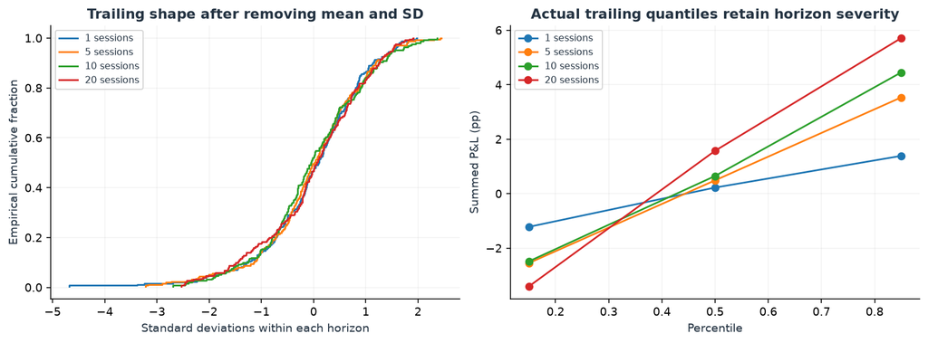

```python
display(pd.read_json(OUT/'macro_scenario_scores_260_7.json').query("leg=='net' and subset in ['all','2017_2022']").round(4))
show_figure(E.distribution_plot(DATE),'04_distribution')
```

### Reconstructed portfolios: corporate-action checks

An initial price-times-quantity heuristic missed reverse splits when a genuine price move occurred on the same date. Checking issuer/regulatory text exposed the problem:

| Stock / date | Apparent daily price return | Verified reverse split | Split-adjusted price return |
| --- | --- | --- | --- |
| CHK, 2020-04-15 | +12,500% | 1 for 200 | −37.00% |
| NBR, 2020-04-23 | +5,457% | 1 for 50 | +11.14% |
| TXMD, 2022-05-09 | +3,127% | 1 for 50 | −35.47% |

Sources: [Chesapeake SEC filing](https://www.sec.gov/Archives/edgar/data/895126/000089512621000078/chk-20201231.htm), [Nabors announcement](https://investor.nabors.com/2020-04-20-Nabors-Announces-Results-of-Special-Meeting-of-Shareholders-and-1-for-50-Reverse-Stock-Split-of-its-Common-Shares), [Nasdaq notice](https://www.nasdaqtrader.com/TraderNews.aspx?id=ECA2022-89).

After these three corrections, the equal-weight proxy's correlation with the public factor rises from .695 to .852 on 1,491 matched dates. Its November 2020 twenty-session tail mean changes from −58.90 to −33.01 pp. I did not use these tail estimates as a reconstruction of the public factor because identity and restructuring issues remain, including an unexplained WLL discontinuity left in the return series and flagged as unresolved. The later PCA screens exclude some observations; they do not resolve the remaining return-quality problems.

**Manual check using an issuer announcement:** Nabors' announcement is dated **20 April 2020** and says “a reverse stock split ratio of its common shares of 1-for-50”. It specifies split-adjusted trading from 23 April. I checked the quoted passage against the issuer page while preparing this notebook. I do not have a historical record of when the document was received. Given price ratio 55.57, the corrected return is 55.57/50−1 ≈ +11.14%, not +5,457%. I used the announcement to check the return calculation. An automated extractor could identify the ratio and effective date for review. I performed this check manually; the proposed text pipeline has not been evaluated here.

The initial split heuristic used the ETF’s shares held in each stock (“quantity”) and its reported stock price. It flagged price ratios above 1.15 or below 1/1.15 when price-ratio×quantity-ratio was within 5% of one, then matched a nearby split ratio within 5%. ETF trades and flows can resemble this pattern. The portfolio definitions and coverage rules follow below.

### Reconstructed portfolios: concentration and common exposures

I used historical holdings of IWV, the iShares Russell 3000 ETF, to construct approximate winner and loser portfolios. Only 36 dates pass the one-year coverage checks. Dividends, delistings and unresolved price changes limit the results. These portfolios have different constituents from the public factor used above. I could not establish which code version generated the inherited membership cache. I therefore treat this branch as exploratory; it does not validate the public-factor forecasts. The construction and results remain below, with summaries in Appendix E09 and E14–E15.

1. **What changed?** For consecutive accepted portfolio dates, I retained the combined set of names with at least 95% of each leg's weight at each date and sufficient history. Entrants/exits remain when covered. I separated the variance change into weight and covariance changes. Let $w_0,w_1$ be the old/new signed portfolio weights and $\Sigma_0,\Sigma_1$ their return covariance estimates on the same names. I calculated $A=w_0'\Sigma_0w_0$, $B=w_1'\Sigma_0w_1$, $C=w_0'\Sigma_1w_0$, $D=w_1'\Sigma_1w_1$. Membership/weight effect is $[(B-A)+(D-C)]/2$; covariance effect is $[(C-A)+(D-B)]/2$. They sum exactly to $D-A$, in **variance pp²**, not standard deviation. I used names with adequate data at both dates for this retrospective decomposition. It does not identify why portfolio weights changed.
2. **Where are adverse contributions concentrated?** At horizons of 1, 5, 10 and 20 trading days, I selected the same worst 15% net windows for every constituent. I averaged each name's contribution and divided the five largest negative magnitudes by the sum of **all negative name averages**, not by net loss. I repeated the calculation after omitting the largest group of overlapping windows, keeping the remaining selected windows fixed. The largest-name sensitivity separately shows fixed-tail accounting and a reselected tail, with that name set to zero and no reweighting.
3. **Do common exposures offset?** I fitted a shared correlation-PCA basis to the covered stock-return panel and projected both signed legs onto the first three PCs. I calculated $1-\mathrm{Var}(L+S)/(\mathrm{Var}(L)+\mathrm{Var}(S))$, plus absolute net component SD. Positive values mean covariance offsets some risk; negative values mean reinforcement. I repeated the calculation after removing market returns to examine the remaining common movement. The components can change across dates, particularly when adjacent components explain similar amounts of variance. I have not assigned them fixed economic meanings.
4. **Forecasting test.** Raw PC1 share largely repeats average correlation; I did not use PC1 share as an additional input. Strict next-month constituent coverage leaves only two valid formations in the prior PCA check, so I did not use PCA as a forecast input. Historical tails of a fixed formation book are not its realised rebalancing history, and the data screen may exclude genuine large moves.

All 23 accepted consecutive-portfolio comparisons and failed coverage checks are recorded. Calculation code: `scripts/book_level_analysis.py`; dated display: `scripts/book_diagnostics.py`; summaries: book-level findings: Appendix E15 and PCA investigation: Appendix E14.

**Portfolio construction, coverage and PCA calculation**

**The two stock constructions differ.** The corporate-action correlation uses a monthly reconstructed portfolio over February 2014–December 2022. It ranks split-adjusted price changes from twelve months before formation to one month before formation, requires at least 95% formation-price coverage and 500 eligible names, and selects the highest/lowest floor(n/10) stocks. Weights are equal within each leg for the quoted correlation. Membership and weights are fixed for each holding month. On each usable day, at least 95% of each leg's weight must have observed returns; weights are then renormalised within the observed subset. The 1,491 observations are matched usable daily returns, not a continuous 1,491-day period. The saved audit reports the count and eligible months rather than a separate exact-date ledger.

The later PCA work reuses cached month-end winner/loser membership. The available upstream code takes the last 273 price rows through formation, calculates returns within that slice and retains the first 252 rows, excluding the final 21 rows. The first retained return is missing, leaving at most 251 observed returns. This describes the available code; I have not independently established the version that generated the cache. It requires 80% observed formation returns, screens absolute daily moves above 60%, and ranks eligible IWV members at the formation date into deciles. Missing screened formation returns are treated as zero within the product. I did not regenerate this cached membership in the submission; that convention is a limitation of the inherited proxy. The PCA weights are proportional to each stock's reported price times the number of its shares held by IWV, rather than the equal weights used for the audit correlation.

I attempted 101 cached portfolio dates from 31 January 2014 to 31 December 2022; 36 passed. A usable snapshot is at most seven calendar days old and has positive formation values for at least 90% of each original leg's names. The preceding 252-trading-day calendar must have at least one observed stock return on 90% of dates. Retained names must have complete returns on that observed subset of dates, nonzero variation, no absolute return above 45%, and no unresolved inferred split. Each retained leg needs thirty names and 80% of its known formation value. I renormalise each accepted leg to unit absolute weight.

Consecutive-date variance comparisons use daily sample covariances over each date's preceding 252-day window, restricted to names complete at both dates. Each of the four date/leg combinations must retain 95% of accepted weight; remaining weights are renormalised separately. In the PCA offset formula, L and S denote only returns represented by the first three components. I standardise each stock, project onto the eigenvectors, then multiply loadings by stock return standard deviations and signed weights to recover pp units. Market removal is an OLS regression of each stock on an intercept and market return over the same window, before PCA.

In the following table, “Largest episode loss share” is the largest overlap group’s fractional-weighted negative net loss divided by that amount across all selected windows. It is not the denominator used for stock-level concentration.

The linked appendix sections summarise these tests; the optional research archive contains the saved supporting tables and figures.

```python
display(Markdown(B.card(DATE)))
display(Markdown(f"**Default-date proxy horizon check: {DATE}.** Fixed formation weights applied to trailing returns; not realised strategy history or the public-factor forecast. This table stays at {DATE} when the historical selector above moves."))
record=B.snapshots.get(DATE)
if record and record['gate']['passed']:
    horizon_rows=[]
    for t in record['tails']:
        omitted=t['omit_episode']
        horizon_rows.append({'Sessions':t['h'],'Net tail pp':round(t['tail_mean'],2),
            'Top-five adverse share':f"{t['top5_share']:.1%}",
            'After episode omission':f"{omitted['top5_share']:.1%}" if omitted and omitted['top5_share'] is not None else 'Unavailable',
            'Largest episode loss share':f"{t['largest_episode_share']:.1%}" if t['largest_episode_share'] is not None else 'Unavailable'})
    display(pd.DataFrame(horizon_rows))
else:
    display(Markdown('No approved constituent snapshot at this date.'))
```

Reconstructed IWV portfolio: dated calculations

These calculations use approximate winner/loser portfolios reconstructed from IWV holdings. Their constituents differ from those of the public momentum factor.

**Portfolio date 2022-12-31; price data through 2022-12-30.** The data cover 99.1% of known long-leg value and 96.6% of known short-leg value. Dividends, delistings and unresolved corporate actions limit the reconstruction.

1. **What changed?** Using stocks with adequate data at both dates, estimated variance changed **+0.93 pp²** from 2022-11-30: membership/weight updates contributed **+1.06**, and covariance changes contributed **-0.13**.

2. **Stock contributions.** In the selected five-trading-day loss windows, the five largest negative contributors (PYPL, SNOW, SQ, DDOG, TEAM) account for **34.6% of the sum of negative average stock contributions**. After removing the largest connected episode, the top-five share recomputed across all names is **34.6%**. The denominator excludes positive contributions, so this percentage differs from a share of net loss.

3. **Do the legs offset?** Across the first three principal components, covariance between the legs reduces their combined variance by **+25%** relative to the sum of the two leg variances. Net component SD is **3.25 pp/day**. After removing market returns, the reduction is **-45%**, and SD is **2.40 pp/day**. A negative reduction means the covariance increases risk. After removing the market, the third and fourth components are close in strength, so the selected three-component set may be unstable.

I would compare these stock and sector exposures with actual holdings before applying the result to another portfolio. The research files contain the 1-, 5-, 10- and 20-trading-day calculations and omission checks.

**Default-date proxy horizon check: 2022-12-31.** Fixed formation weights applied to trailing returns; not realised strategy history or the public-factor forecast. This table stays at 2022-12-31 when the historical selector above moves.

|  | Sessions | Net tail pp | Top-five adverse share | After episode omission | Largest episode loss share |
| --- | --- | --- | --- | --- | --- |
| 0 | 1 | -5.31 | 33.9% | 33.9% | 6.0% |
| 1 | 5 | -9.38 | 34.6% | 34.6% | 20.4% |
| 2 | 10 | -9.58 | 37.2% | 34.1% | 30.3% |
| 3 | 20 | -7.80 | 38.1% | 28.5% | 40.7% |

### Interim losses over twenty trading days

A 20-day endpoint return can conceal an earlier loss. I measured both the lowest cumulative return at a daily close during each window and its final return. Average estimated breach probability in 2023–July 2026 is 19.6%, against 9.3% observed. That overprediction limits how much confidence I would place in the estimates.

1. At each weekly cutoff, I measured the next 20 trading days of fixed-notional net P&L. I calculated $L_t=\min(0,\min_{1\leq j\leq20}\sum_{s=1}^{j}r_{t+s})$ and $R_t=\sum_{s=1}^{20}r_{t+s}$. I compared $L_t\leq-5$ with $R_t\leq-5$, in pp. These are daily-close barriers, not intraday lows or the main model's approximately-weekly −2.16 pp target.
2. For filtered historical simulation (FHS), I used at most 1,260 **completed weekly-start paths**—roughly 24 years, not 1,260 trading days. I divided each path by daily EWMA sigma at its starting cutoff, rescaled it by current sigma, and calculated $(\text{breaches}+.5)/(N+1)$. I used the same paths to estimate endpoint risk so the two estimates referred to the same historical outcomes. Whole-path scale adjustment preserves historical within-path movement but does not model future volatility dynamics. Overlapping paths are not independent.
3. I evaluated the estimates chronologically on 2,030 cutoffs, excluding unfinished return windows from training. I compared them with volatility-logistic and exposure/shape models. The FHS pooled log loss is .28328 versus .28800 for volatility; its difference has a 52-week block interval [-.01059,+.00200]. The interval does not establish an improvement over the comparator. Richer predictors do not improve pooled results. 260/520-path histories give similar scores; a scale-relative barrier is also tested.
4. I found that **244 windows breach −5 pp, but only 149 finish below it**. The other 95 recover above the barrier before the endpoint—38.9% of breaches. These are overlapping windows, not independent crashes.
5. I measured both legs at each window’s first breach, subsequent low and endpoint, using the same dates for both legs. First-breach mean contributions are +.43 pp long / −6.44 pp short. The short contribution is more negative in 76% of breached windows. Equal weighting of 58 overlap clusters preserves short-side dominance (-.29 / -5.47 pp), but makes low-to-endpoint improvement more balanced between legs. These are realised outcome-conditioned descriptions, not predictions of future contributors or evidence of forced covering.

**Warning performance:** an illustrative, unoptimised 25% alert cutoff captures half of breached windows, with about 40% precision. The late-2008/2009 overlap group has a pre-breach alert; spring 2020 narrowly misses the cutoff. The groups are selected retrospectively for dependence checks, not detected economic regimes. Omitting each of the five largest loss clusters leaves the small descriptive FHS advantage, but does not change its uncertain pooled significance.

**Rejected duration extensions:** recovery-to-old-high hazards conflate events into a 2008–2022 episode; age adds no robust gain. Observable local stress-transition models mostly predict proximity to a threshold and known rolling-window expiry; age/exposure/shape add no dependable improvement. I did not include duration or transition models in the assessment.

Summaries: path forecast tests: Appendix E18, leg/episode/warning checks: Appendix E19, recovery hazards: Appendix E17.

### GARCH estimate of the same loss event

I also estimate path risk by simulating daily returns from a Student-t GARCH(1,1) model. Its variance changes during each simulated path:

$$r_{t+1}=\sqrt{h_{t+1}}z_{t+1},\qquad h_{t+1}=\omega+\alpha r_t^2+\beta h_t.$$

Here $h$ is daily conditional variance and $z$ is a Student-t draw scaled to unit variance. The conditional mean is set to zero.

1. I fitted the parameters annually to daily net-factor returns ending at the first weekly cutoff of each year. Later forecasts use those parameters and update variance with returns observed through their cutoff.
2. I simulated 8,192 paths of 20 trading days, using fixed random seeds and paired positive/negative innovation draws. I counted paths that reached −5 pp at a daily close and paths that finished at or below −5 pp.
3. I compared these probabilities with the historical-path model on the same dates. I also held simulated variance constant while keeping initial variance and shocks the same, to examine the contribution of within-path volatility changes.
4. I repeated the recent simulation with 32,768 paths and a second seed. The recent log-loss comparison was similar. GJR-GARCH, which allows positive and negative returns to affect variance differently, gave only a small additional difference.

The dated table below reports both models separately. Their difference reflects different assumptions about returns and volatility; it is not a confidence interval. I have not averaged the estimates or selected a model separately for each period.

| Evaluation period | Model | Estimated breach frequency | Observed | Log loss |
| --- | --- | --- | --- | --- |
| 1984–2022: 2,030 cutoffs | Historical paths | 11.75% | 12.02% | .28328 |
| 1984–2022 | GARCH-t paths | 8.95% | 12.02% | .29075 |
| 2023–July 2026: 183 cutoffs | Historical paths | 19.59% | 9.29% | .32231 |
| 2023–July 2026 | GARCH-t paths | 16.67% | 9.29% | .30299 |

GARCH has lower recent error but still overpredicts breaches. Before 2023 it underpredicts frequency and has higher log loss than historical paths. The recent GARCH-minus-historical log-loss difference is −.01932, with a 26-week block interval [−.03074, −.00496]; the earlier difference is +.00747, interval [−.00275, +.01946]. The recent period contains 17 breached overlapping windows. I chose this experiment after seeing recent overprediction; the intervals are pointwise and do not account for that research selection. Appendix E21 records the controls and simulation checks.

The FHS library updates at **each weekly cutoff**, taking the most recent 1,260 twenty-day paths whose last day is already observed. The common evaluation uses at least 100 completed training rows, twenty breaches and twenty non-breaches for the annual logit. The path logit uses log daily EWMA; its richer comparison adds the four-week stress score, net beta, directional gap and averaged left/asymmetry features. The relative barrier sensitivity is $-2\sqrt{20}\sigma_t$. Overlap groups join paths sharing trading days; equal-group attribution first averages within each group, then averages those group means.

GARCH uses expanding daily history from 2 January 1964, zero-mean maximum likelihood and jointly estimated Student-t degrees of freedom. The `arch` implementation initialises variance from its weighted squared-return backcast; the fitted end variance is filtered forward, rather than reset each week. Annual path fits end at the first weekly cutoff **within** the year (6 January 1984 in the first year), predicting the next twenty days; this differs from next-calendar-week model labels. Both conventions use only completed observations at their own forecast cutoff.

The linked appendix sections summarise these tests; the optional research archive contains the saved supporting tables and figures.

**Path estimates at 30 December 2022.** Both concern a −5 pp loss over the next 20 trading days. This historical table stays fixed when the date selector above moves.

|  | Model | Cutoff | Any daily-close breach | Endpoint loss |
| --- | --- | --- | --- | --- |
| 0 | Historical paths | 2022-12-30 00:00:00 | 35.3% | 19.6% |
| 1 | GARCH-t simulated paths | 2022-12-30 00:00:00 | 32.8% | 19.5% |

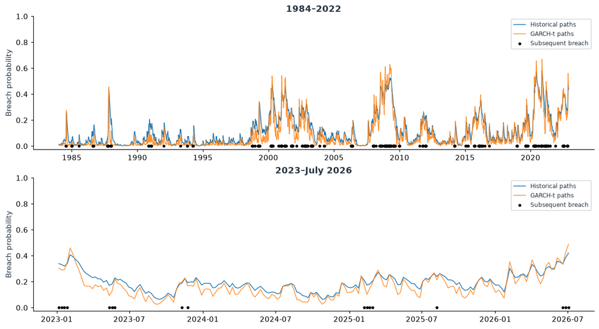

Black marks indicate windows that subsequently breached −5 pp. Adjacent marked windows can contain the same loss episode. Both models overpredict recent breach frequency; GARCH underpredicts it in the earlier period.

```python
path_dir=ROOT/'research/local_stress'
comparison=pd.read_json(ROOT/'research/garch_path/assessment_comparison.json')
assert comparison['date'].nunique()==1
assert comparison['date'].iloc[0]==pd.Timestamp('2022-12-30')
display(Markdown('**Path estimates at 30 December 2022.** Both concern a −5 pp loss over the next 20 trading days. This historical table stays fixed when the date selector above moves.'))
display(comparison.rename(columns={'model':'Model','date':'Cutoff','path_probability':'Any daily-close breach','endpoint_probability':'Endpoint loss'}).style.format({'Any daily-close breach':'{:.1%}','Endpoint loss':'{:.1%}'}))
path_predictions=pd.read_parquet(ROOT/'research/garch_path/predictions.parquet')
fig,axes=plt.subplots(2,1,figsize=(11,6),layout='constrained')
for ax,lo,hi,title in [(axes[0],'1984','2022','1984–2022'),(axes[1],'2023','2026','2023–July 2026')]:
    rows=path_predictions.loc[lo:hi]
    ax.plot(rows.index,rows.p_fhs,label='Historical paths',lw=1)
    ax.plot(rows.index,rows.p_garch_t,label='GARCH-t paths',lw=1,alpha=.85)
    ax.scatter(rows.index[rows.y==1],np.zeros(int(rows.y.sum())),s=8,color='black',label='Subsequent breach',zorder=3)
    ax.set(title=title,ylabel='Breach probability',ylim=(-.025,1))
    ax.legend(fontsize=8)
show_inline(fig)
display(Markdown('Black marks indicate windows that subsequently breached −5 pp. Adjacent marked windows can contain the same loss episode. Both models overpredict recent breach frequency; GARCH underpredicts it in the earlier period.'))
```

### Options data: what the available quotes support

This final investigation uses **MTUM, a long-only momentum ETF**, and a saved **2026** snapshot. It is not the public long–short factor or the reconstructed IWV book. No options input enters their historical forecasts, regressions or evaluation. A production system could compare market-priced risk with historical risk on the **same underlying, date and horizon**; I have not performed that comparison here.

1. **Available observations.** The 17 saved MTUM files contain seven distinct underlying last-trade dates, with repeated payloads. Latest underlying trade: September 9, 2026; payload timestamp: September 10, timezone unspecified. Contract quote timestamps are absent. Last-trade time is not quote time. I cannot call this a clean daily history.
2. **Quote coverage.** Require positive, non-crossed bid/ask and displayed sizes, then inspect 10%/25%/50%-of-mid spread cutoffs. At 25%, the 30-day expiry has no paired ATM or 25-delta call/put IV estimate. At 50%, paired vendor ATM IV is about 28.36%, but paired skew still fails. I varied the spread cutoff to check quote coverage. Too few out-of-the-money quotes pass the screens to estimate the distribution reliably.
3. **Put-spread payoff.** In the October 9 expiry, a $295/$277.50 put spread covers an interval approximately 4.6%–10.3% below the recorded $309.29 ETF price. Its expiry payoff per share is $\max(295-S_T,0)-\max(277.5-S_T,0)$, capped at $17.50 before premium.
4. **Bid and ask prices.** Put bid/ask quotes are $2.65/$6.50 and $0.25/$3.60 respectively. Their midpoint difference is **$2.65** (0.86% of ETF price), while buying at ask and selling at bid costs **$6.25** (2.02%). Simultaneous fills are unverified. Both contracts report zero volume/open interest and no last-trade timestamp; both fail even the 50% spread screen. The quotes are too wide to support a reliable protection-cost estimate.
5. **Interpreting option prices.** Option-implied distributions price risk under the risk-neutral measure; they are not physical crash probabilities. MTUM options also require American-exercise and dividend treatment before applying European density-extraction formulas. The necessary strike-shape tests can fit within the wide quote bands, but that does not identify a precise curvature or tail probability.

I included this example because the bid–ask spread materially changes the apparent protection cost. I could calculate a provisional at-the-money volatility indication, but the available quotes were insufficient to estimate the downside distribution reliably. That calculation would require synchronised quotes and verified contract inputs.

The earlier option-summary procedure selected positive vendor IVs by delta without bid–ask or freshness screening; I reuse its raw archive, and recalculate the quote-quality checks. Audit summary: Appendix E16. Method context: [New York Fed on risk-neutral distributions](https://www.newyorkfed.org/research/staff_reports/sr677.html), [OIC on ETF exercise](https://www.optionseducation.org/referencelibrary/faq/options-exercise), [Federal Reserve on physical versus risk-neutral probabilities](https://www.federalreserve.gov/econres/ifdp/files/ifdp1294.pdf).

For each expiry and spread screen, I selected the eligible call/put nearest delta +.50/−.50 within .15 and +.25/−.25 within .10. Paired ATM IV is the arithmetic mean of the selected 50-delta call and put vendor IVs; skew is 25-delta put IV minus 25-delta call IV. A pair is missing if either side is unavailable. The spread screen is (ask−bid)/mid, with positive non-crossed quotes and positive displayed sizes.

The linked appendix sections summarise these tests; the optional research archive contains the saved supporting tables and figures.

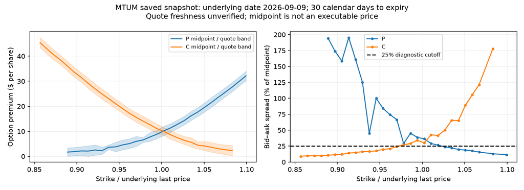

Many contracts with narrow spreads are in-the-money. Fewer of the out-of-the-money downside puts pass the screens, limiting the information about the left tail. The 25% line marks the spread screen used in the audit.

```python
options_dir=ROOT/'research/options_poc'
options_audit=json.loads((options_dir/'audit.json').read_text())
assert len(options_audit['captures'])==17
assert options_audit['unique_sessions']==7
display(Image(filename=str(options_dir/'quote_quality.png')))
display(Markdown('Many contracts with narrow spreads are in-the-money. Fewer of the out-of-the-money downside puts pass the screens, limiting the information about the left tail. The 25% line marks the spread screen used in the audit.'))
```

## Data limitations and possible extensions

The public data support the calculations above, but do not contain actual portfolio positions or reliable momentum-book positioning. Better data would improve measurement of those exposures; whether they improve prediction would require another test.

| Current gap | Production input or change | What it could improve | What it would not establish by itself |
| --- | --- | --- | --- |
| Published factor is not the PM's book | Actual point-in-time positions, notionals, identifiers and mandate | Relevant exposure, scenarios and contribution accounting | A predictive edge or a causal catalyst |
| Incomplete price-based constituent proxy | Audited total returns, delistings, corporate actions and historical membership | Trustworthy reconstruction and larger usable coverage | That PCA components are permanent economic factors |
| Crowding is inferred, not observed | Properly licensed borrow fees/availability, short interest, flow and ownership data with release timestamps | Test positioning vulnerability and competing mechanisms | Proof that an observed loss was forced covering |
| Sparse, wide MTUM option quotes | Synchronized chains, contract terms, rates and dividends | Market-priced protection and implied distributions with bid–ask and model sensitivity reported | Physical crash probabilities or a long–short-factor distribution |
| Current-vintage macro and hand-built research runs | Vintage-aware ingestion, availability ledger and reproducible daily jobs | More credible historical replay and dependable monitoring | Additional predictive information without evaluation |
| Numerical patterns do not identify catalysts | Permitted timestamped filings, releases and news linked to current holdings | Evidence-led investigation of shared risks and contradictions | Causality or automatic probability adjustments |

### Connection to the first-stage text proposal

In the [first-stage design schematic](https://t1mchee.github.io/momentum-design/), I proposed identifying shared risks in company filings and news, then relating those themes to the stocks contributing to common portfolio exposures. The proposal compares themes with matched random portfolios and keyword-based extraction, retaining source quotes so the interpretation can be checked. Text and positioning do not enter its numerical tail model.

This notebook is the second stage: implementation and evaluation of the classical statistical methods. It shares the proposal's volatility-scaled historical-return approach, but the targets differ. The design uses ten-day reconstructed-book returns; here I evaluate weekly public-factor downside and twenty-day interim losses. The stock-level work remains a limited proxy, not a completed implementation of the design.

The possible connection is at the company level. For example, if several short-leg stocks contribute to a loss or common exposure, their dated filings and news could help assess whether they share an economic risk. I have not tested that connection here, and a shared theme would not establish what caused the loss. The corporate-action checks above illustrate a narrower use: source text helped verify return calculations. The proposed extraction, theme comparisons and model-training look-ahead risks would need their own evaluation, preferably prospectively.

### Conclusion

I implemented weekly downside estimates, historical leg-loss contributions and conditional market responses. The comparisons led me to keep the simple volatility and rolling-beta models. The historical analysis describes differences between the legs that an aggregate volatility estimate does not show. Recent path probabilities overpredict breaches, and scenario results vary with the estimation window. These results leave substantial uncertainty about future performance, especially in rare events.

Applying the calculations to a PM's portfolio would require reliable dated holdings and returns. Assessing usefulness would also require feedback on actual research decisions; that has not been done here.

### Reproduction and assistance

SUBMISSION_README.md lists the files and execution instructions. The appendix records the experiments and additions made after earlier results were examined. A coding assistant helped with implementation, tests and drafting. Role-based AI reviews checked the work; these were not independent human validation. The numerical estimates use classical statistical methods without text-derived inputs.

[Daniel and Moskowitz](https://www.nber.org/papers/w20439.pdf) motivates the exposure and rebound question; [Moreira and Muir](https://www.nber.org/papers/w22208) motivates volatility as a comparator. The notebook's own tests produce the reported results.

```python
display(pd.DataFrame({'Passed numerical check':[s.replace('Original Notebook 08 evaluation','Previously saved evaluation').replace('Notebook 08','previously saved results').replace('four prefix checks','four checks using history truncated at earlier dates') for s in qa['checks']]}).style.set_properties(**{'white-space':'normal','text-align':'left'}))
assert E.daily.index.max()==pd.Timestamp('2022-12-30')
assert len(E.predictions)==2035
assert np.allclose(E.predictions.dynamic_long+E.predictions.dynamic_short,E.predictions.dynamic)
assert np.isfinite(E.predictions.dynamic).all()
print('All checks passed; exploratory history and current-vintage data limitations remain.')
```

|  | Passed numerical check |
| --- | --- |
| 0 | Previously saved evaluation, scenarios and validation predictions byte-identical |
| 1 | Rolling directional betas independently reproduced by direct daily OLS; four checks using history truncated at earlier dates |
| 2 | Future daily prices/returns and future weekly outcomes cannot change earlier states/responses |
| 3 | Forward first-three-year prefix replay matches full saved logistic and quantile predictions |
| 4 | Macro future perturbation leaves earlier lagged inputs unchanged; dated source hashes recorded |
| 5 | Dated scenario engine replays saved conditional predictions; additive legs and ordered mean intervals |
| 6 | Probabilities bounded; independent q05 pinball calculation agrees |

```
All checks passed; exploratory history and current-vintage data limitations remain.
```